# ゲームハード週販レポート (2025.10.19)

国内ゲームハード週販レポート (2025-10-19)

- ハードウェアの販売データはファミ通の調査結果を基にしています。
- 一部のデータは処理上の都合により、週次値に調整しています。
- 過去の週販レポート

## 直近4週間のハード売り上げ／累計推移

ポケモンZA同梱版も含め今まで貯めた分の大量出荷が行われ、Switch2の販売数が20万台を超えました。 Switch2の週販20万台はロンチの71万台に次ぐ2番目の値です。累計も240万台を超えました。

来週以降、通常の2倍超の10万水準の出荷に切り替わり年末商戦モードに入るのか、それとも、多いのは今週だけで、また5万台水準に戻るのか、次週の注目点です。

PS5 AUTUMN SALEの効果は特に無く、先週より若干低下。

Switchは先週から変化なし。すごく安定しています。 Switch2発売直後はその影響で2万を切ってた時期もあるのですが、 ZAでのSwitch2大量出荷の影響は受けていません（なぜ？）。

| 集計日 | ハード | 販売台数 | 累計台数 |
| --- | --- | --- | --- |
| 2025-09-28 | Nintendo Switch2 | 44,150 | 2,109,622 |
|  | Nintendo Switch | 23,110 | 36,028,444 |
|  | PlayStation5 | 16,911 | 7,056,935 |
|  | Xbox Series X\|S | 441 | 684,515 |
|  | PlayStation4 | 21 | 9,490,834 |
| 2025-10-05 | Nintendo Switch2 | 44,439 | 2,154,061 |
|  | PlayStation5 | 27,344 | 7,084,279 |
|  | Nintendo Switch | 24,109 | 36,052,553 |
|  | Xbox Series X\|S | 837 | 685,352 |
|  | PlayStation4 | 19 | 9,490,853 |
| 2025-10-12 | Nintendo Switch2 | 46,842 | 2,200,903 |
|  | Nintendo Switch | 23,149 | 36,075,702 |
|  | PlayStation5 | 14,800 | 7,099,079 |
|  | Xbox Series X\|S | 237 | 685,589 |
|  | PlayStation4 | 17 | 9,490,870 |
| 2025-10-19 | Nintendo Switch2 | 201,684 | 2,402,587 |
|  | Nintendo Switch | 23,713 | 36,099,415 |
|  | PlayStation5 | 12,085 | 7,111,164 |
|  | Xbox Series X\|S | 188 | 685,777 |
|  | PlayStation4 | 23 | 9,490,893 |

## 2025年の週販推移

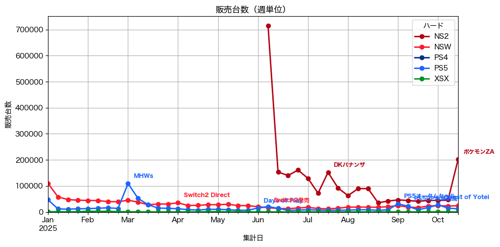

### 2025年の週販推移(拡大）

ZA効果でSwitch2が20万台に達しました。20万がグラフに収まるように拡大率を調整した影響で、 Switch2以外の状況が見にくくなってしまいました。 Switchは不思議な程に安定しています。Switch2による買い控え効果は顕在化していません。

PS5はAUTUMN SALEの効果はほぼ無し。Ghost of Yoteiの影響も弱くなりいつもの値に戻りつつあります。

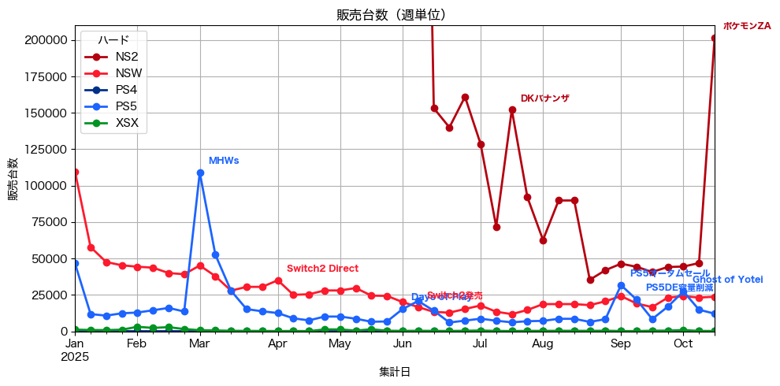

## 2025年月間販売推移

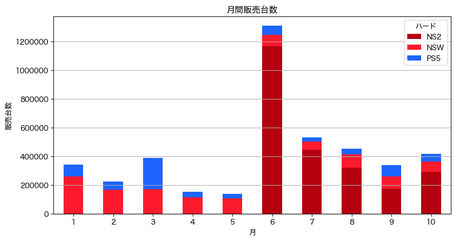

| hw month | NS2 | NSW | PS5 |
| --- | --- | --- | --- |
| 1 | 0 | 260,447 | 81,587 |
| 2 | 0 | 167,188 | 56,886 |
| 3 | 0 | 171,921 | 218,300 |
| 4 | 0 | 113,513 | 38,983 |
| 5 | 0 | 106,506 | 32,001 |
| 6 | 1,169,684 | 78,097 | 63,516 |
| 7 | 444,706 | 57,532 | 28,959 |
| 8 | 319,690 | 94,517 | 39,004 |
| 9 | 175,542 | 82,946 | 78,693 |
| 10 | 292,965 | 70,971 | 54,229 |

### Nintendo Switchの月間販売台数： 2023,2024年との比較

Switch2大量出荷にも関わらずSwitchの販売台数は安定しています。 昨年比で減少は当然ですが、10月は9月よりはマシな前年比になりそうです。

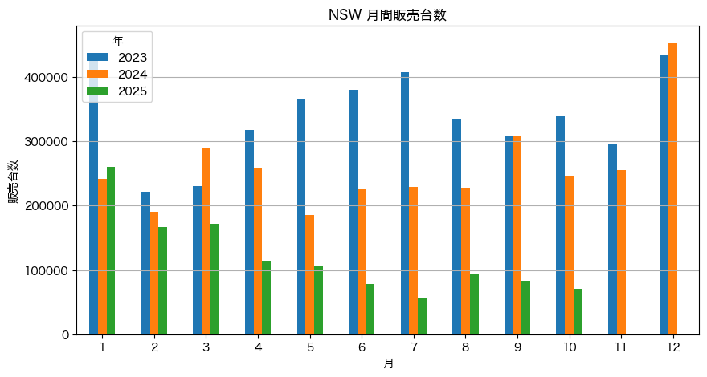

### PlayStation 5の月間販売台数： 2023, 2024年との比較

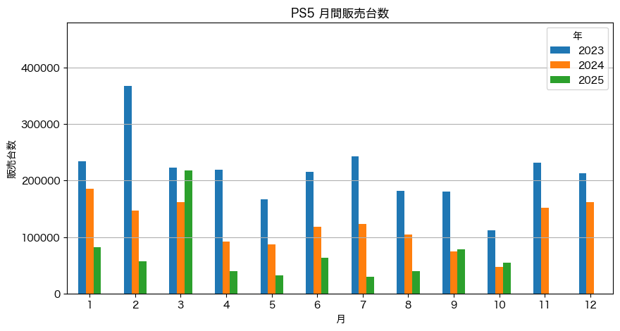

## 累計販売推移

Switch2 20万台の大量出荷がありましたが、累計グラフの見た目の変化はまだ大きくありません（右端が気持ち上がったかな程度）。 今後のSwitch2 年末商戦で変化があるでしょう。

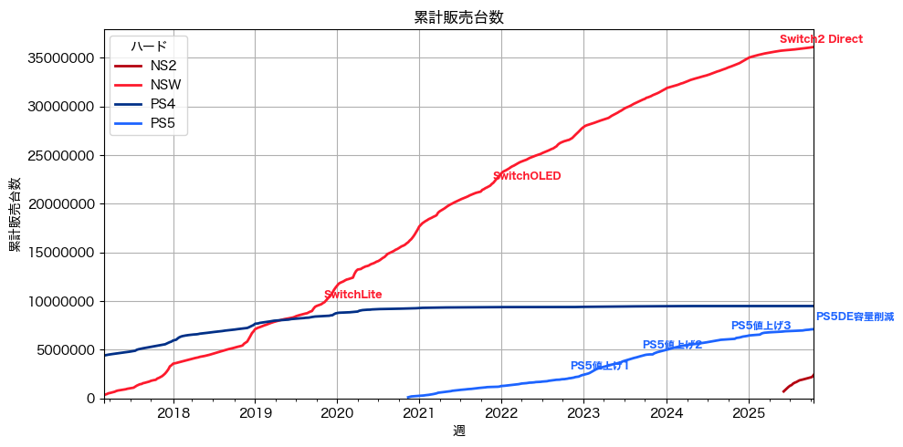

## Switch2販売状況

### 歴代機種との比較

ZA発売週の20万台がグラフの傾きにハッキリと現れています。 今後、初動歴代2位から3位に落ちる可能性はないでしょう。 歴代1位を狙えるかどうかが焦点になります。

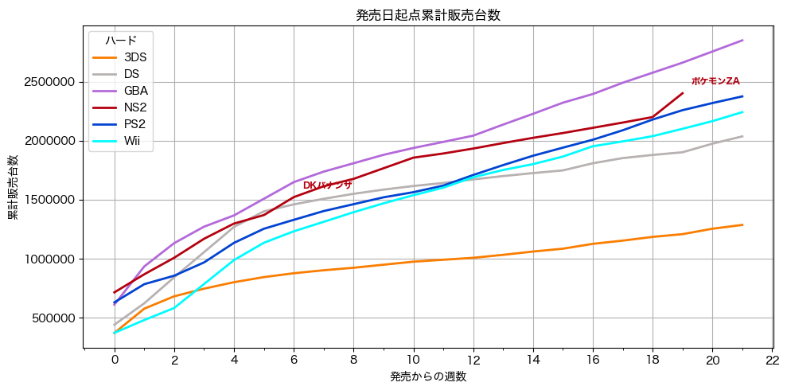

| ハード | 週数 | 販売数 |
| --- | --- | --- |
| GBA | 19 | 2,661,906 |
| NS2 | 19 | 2,402,587 |
| PS2 | 19 | 2,259,168 |
| Wii | 19 | 2,101,312 |
| DS | 19 | 1,902,542 |
| 3DS | 19 | 1,208,655 |

## Switch/Switch2ロンチ比較

#### Switch2 20万台の大量出荷

ロンチ週以降のSwitchとSwitch2の販売状況の比較です。

ついに到来したZA発売週。Switch2の週販第2位の20万台が目立ちます。 年末年始中は、以前のように5万台水準に戻ることはないと思いますが、10万台前後の出荷が継続することを期待したいですね。

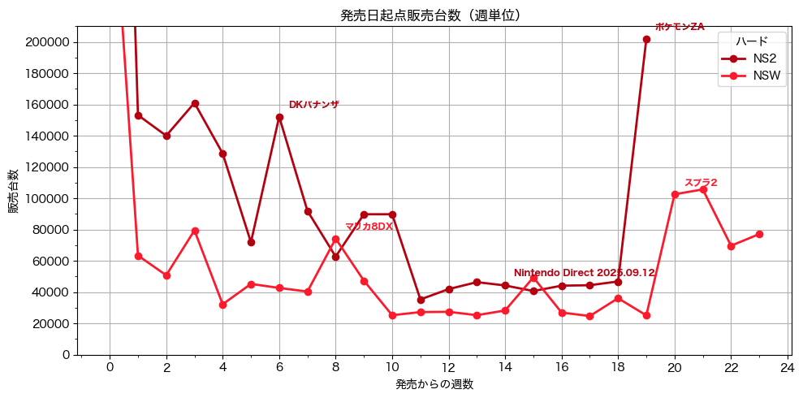

## 年単位の状況

全機種合わせた年毎のハード販売の状況です。 2025年は500万台を超える見込みですが、600万台到達は難しそうです。 （しかし、ブルームバーグ報道のようにSwitch2を年度内2000万台（ワールドワイドで）販売できるのならワンチャンあります）

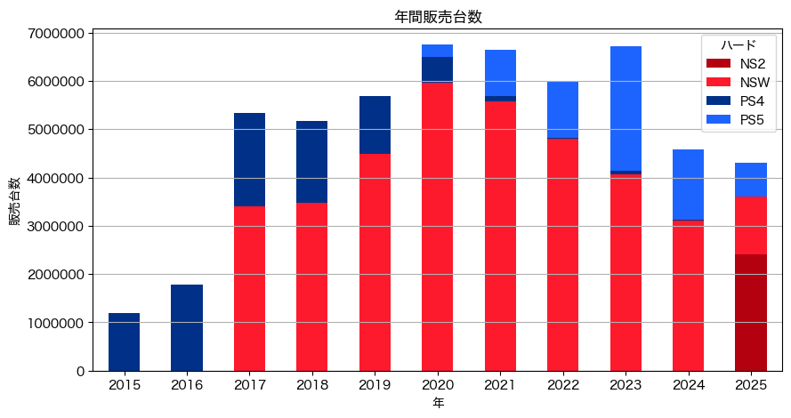